# R Notebook

### (b). Fit a one-way anova model to see if there is a significant difference in the average response rate for at least one colour.

```r
anova_quest <- aov(rate ~ colour, data = color_data)
summary(anova_quest)
```

```
            Df Sum Sq Mean Sq F value Pr(>F)
colour       2    7.6     3.8   0.392  0.684
Residuals   12  116.4     9.7
```

### $H_0$: The average response rate is the same across all colors

### $H_1$: There is a significant difference in the average response rate for at least one color

### WIth a 5% significance level, the p-value is 0.684 > 0.05 so we fail to rejectthe null hypothesis, implying that there is no significant differece in the average response rate for at least one color.

### (c). After the findings in part (b) an executive has made a comment saying that they should have simply printed the questionnaires on white paper. Suppose that you think size of the parking lot might be interfering any relationship there might be between the color of the paper and the average response rate. Use an appropriate graph that displays the relationship between response rate and the lot size for the color of the paper. Comment on your observations.

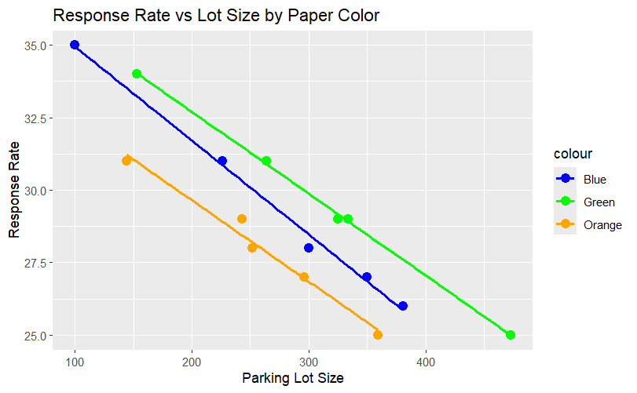

```r
library(ggplot2)

ggplot(color_data, aes(x = lot, y = rate, color = colour)) +
  geom_point(size = 3) +  # Scatter plot of the data points
  geom_smooth(method = "lm", se = FALSE, aes(color = colour), linetype = "solid") +  # Add linear regression line
  labs(title = "Response Rate vs Lot Size by Paper Color",
       x = "Parking Lot Size",
       y = "Response Rate") +
  scale_color_manual(values = c("Blue" = "blue", "Green" = "green", "Orange" = "orange"))
```

### $\beta$: regression coefficient that explains the relation between the response and the covariance

### $\epsilon_{ij}$: random error

```r
library(car)
color_data$Centlot <- scale(color_data$lot, center = TRUE , scale = TRUE)
Qfit <- aov(rate ~ Centlot + colour, data = color_data)
Anova(Qfit)
```

```
Anova Table (Type II tests)

Response: rate
           Sum Sq Df F value    Pr(>F)
Centlot   115.084  1 961.809 4.645e-12 ***
colour     23.392  2  97.748 9.900e-08 ***
Residuals   1.316 11
---
Signif. codes:  0 ‘***’ 0.001 ‘**’ 0.01 ‘*’ 0.05 ‘.’ 0.1 ‘ ’ 1
```

### (f) Based on the fitted model, does it look like the color of the paper matters? Explain your answer.

### Based on the results, at the 95% confidence level, the p-value for colour is $9.9 ^{8-} < 0.05 so we reject the null hypothesis and accept the alternative hypothesis. This suggests that there is a significant difference between the color of the questionnaire and the response rate. Also, the p-value for Centlot is $4.645 ^{-12} < 0.05 so we reject the null hypothesis. This suggests that there is a significant difference between the size of the parking lot and the response rate.

### Question 4: Two types of dementia are dementia with Lewy Bodies and ALzheimer’s. To answer this problem, you will be using LewyBody2Groups data in Stat2Data package. The variable Type has two levels: DLB (only Lew Bodies dementia), DLB/AD (both). Variable MMSE measures the change in functional performance on the Mini Mental State Examination. We are interested in using MMSE to predict whether or not Alzheimer’s disease is present.

### (a). Load the data and print the first couple of observations.

```r
library(Stat2Data)
data(LewyBody2Groups)
print(head(LewyBody2Groups, 10))
```

|  | Type | APC | MMSE |
| --- | --- | --- | --- |
| 1 | DLB | 0.85 | 2.22 |
| 2 | DLB | 0.49 | 0.37 |
| 3 | DLB | 0.12 | -0.10 |
| 4 | DLB | 0.00 | -2.99 |
| 5 | DLB | -0.22 | 0.66 |
| 6 | DLB | -0.35 | -2.47 |
| 7 | DLB | -0.40 | -0.03 |
| 8 | DLB | -0.41 | -1.92 |
| 9 | DLB | -0.43 | -0.09 |
| 10 | DLB | -0.45 | -3.03 |

### (b). Make an appropriate graph to display the relationship between MMSE and the type of dementia. Comment on your observations.

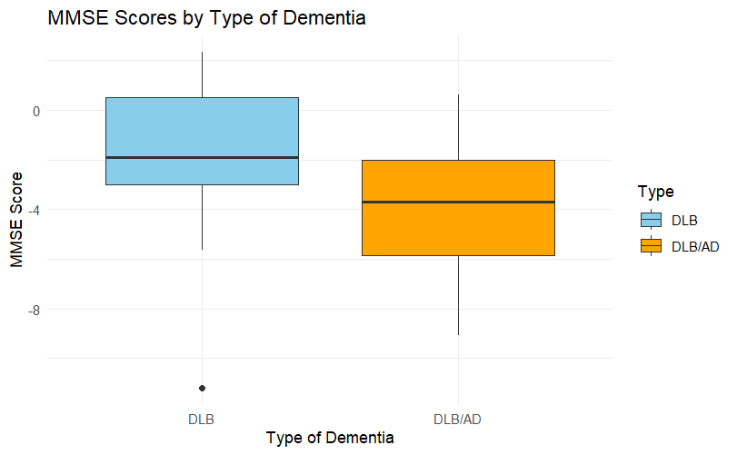

```r
library(ggplot2)

ggplot(LewyBody2Groups, aes(x = Type, y = MMSE, fill = Type)) +
  geom_boxplot() +
  labs(title = "MMSE Scores by Type of Dementia",
       x = "Type of Dementia",
       y = "MMSE Score") +
  theme_minimal() +
  scale_fill_manual(values = c("skyblue", "orange"))
```

### (c). Fit a logistic regression model to this data. For this, you will have to first create a binary variable for the type. Use below code lines for this.

```r
Alz <- LewyBody2Groups
Alz$TypeCode <- ifelse(Alz$Type == "DLB", 0, 1)
log_reg_model <- glm(TypeCode ~ MMSE, data = Alz, family = binomial)
summary(log_reg_model)
```

```
Call:
glm(formula = TypeCode ~ MMSE, family = binomial, data = Alz)

Coefficients:
            Estimate Std. Error z value Pr(>|z|)
(Intercept)  -0.7425     0.4869  -1.525   0.1273
MMSE         -0.2937     0.1332  -2.204   0.0275 *
---
Signif. codes:  0 ‘***’ 0.001 ‘**’ 0.01 ‘*’ 0.05 ‘.’ 0.1 ‘ ’ 1

(Dispersion parameter for binomial family taken to be 1)

    Null deviance: 54.040  on 38  degrees of freedom
Residual deviance: 47.848  on 37  degrees of freedom
AIC: 51.848

Number of Fisher Scoring iterations: 3
```

### (d). Based on the fitted model, does MMSE seem to be a significant predictor in determining the probability of Alzheimer’s disease (use 5% significance level)? Explain your answer.

### Based on the fitted model, the p-value for MMSE is 0.0275 < 0.05, making it a statistically significant predictor in determing the probability of Alzheimer’s disease.

### (e). Use the fitted model to estimate the odds of Alzheimer’s disease if a patient’s MMSE is -4.

```r
MMSE_value <- -4
coefficients <- coef(log_reg_model)
logit <- coefficients[1] + coefficients[2] * MMSE_value
odds <- exp(logit)
print(odds)
```

```
(Intercept)
   1.540882
```

### The estimated odds of Alzheimer’s disease if a patient’s MMSE is -4 is 1.540882

### (f). Use the model to estimate the probability of Alzheimer’s disease if a patient’s MMSE is -4.

```r
MMSE_value <- -4
coefficients <- coef(log_reg_model)
logit <- coefficients[1] + coefficients[2] * MMSE_value
probability <- 1 / (1 + exp(-logit))
print(probability)
```

```
(Intercept)
  0.6064358
```

### The estimated probability of Alzheimer’s disease if a patient’s MMSE is -4 is 0.6064358

### (g). How much does the estimated odds change if the MMSE changes from -4 to -3?

```r
MMSE_value1 <- -4
MMSE_value2 <- -3

logit1 <- coefficients[1] + coefficients[2] * MMSE_value1
logit2 <- coefficients[1] + coefficients[2] * MMSE_value2

odds1 <- exp(logit1)
odds2 <- exp(logit2)

odds_change <- odds2 / odds1
print(odds_change)
```

```
(Intercept)
  0.7454918
```